# Xenium post-processing

Shubhada Kulkarni

23 July 2024

## INFO

This Quarto computational documents includes post-processing of already clustered Xenium data generated using `process_Xenium_data.R` script. This post-processing includes

- [] Merging and batch-effect correction of data per slide.
- [] Post-merging processing
- [] Cell-type annotations

## Cell-type annotations

Loading required libraries

```r
library(ggplot2, lib.loc = "/beegfs/homes/skulkarni/R/x86_64-pc-linux-gnu-library/4.3")
library(Seurat, lib.loc = "/beegfs/homes/skulkarni/R/x86_64-pc-linux-gnu-library/4.3")
library(patchwork)
library(markdown)
library(rmarkdown)
library(dplyr, lib.loc = "/beegfs/homes/skulkarni/R/x86_64-pc-linux-gnu-library/4.3")
library(presto, lib.loc = "/beegfs/homes/skulkarni/R/x86_64-pc-linux-gnu-library/4.3")
```

### Slide 0027119 (7/3 male R231Q/wt)

Read in stored Xenium objects for both regions for *0027119*

```r
region1 <- readRDS("/prj/XeniumProbeDesign/kidney_Nphs2-mice_Xenium_Martin/xenium_objects_R/output-XETG00046__0027119__Region_1__20240621__120943_processed.rds")
region2 <- readRDS("/prj/XeniumProbeDesign/kidney_Nphs2-mice_Xenium_Martin/xenium_objects_R/output-XETG00046__0027119__Region_2__20240621__120943_processed.rds")
```

```r
p1 <- DimPlot(region1) + labs(title = "Region 1")
p2 <- DimPlot(region1) + labs(title = "Region 2")
p1 + p2
```

[output not shown]

#### Merging the two regions and post-processing

A separate R script was used to perform merging of two regions, as memory was running out. This R script was submitted as a SLURM job. Output of this script is a processed merged Xenium objects that contain both regions. Following operations have been performed during above processing: * Merging * Normalising and scaling data * Re-computing PCA and UMAP * Finding neighbors * Finding clusters

```r
xenium.obj.0027119 <- readRDS("/prj/XeniumProbeDesign/kidney_Nphs2-mice_Xenium_Martin/xenium_objects_R/0027119_merged_processed.rds")
```

Finding marker genes using presto package (much faster than Seurat functions)

```r
all_markers_0027119 <- presto::wilcoxauc(xenium.obj.0027119,  seurat_assay = "SCT", group_by = "seurat_clusters")
write.csv(all_markers_0027119, "/prj/XeniumProbeDesign/kidney_Nphs2-mice_Xenium_Martin/xenium_objects_R/0027119_merged_markergenes.csv", quote = F)
```

#### Cell-type annotations

For selection of marker genes per cell-type, I looked into multiple papers publishing scRNA-seq mouse kidney. However, after trying multiple ones, following paper had the most overlapping cell-types https://www.ncbi.nlm.nih.gov/pmc/articles/PMC10690238/#SD1

Function to plot expression levels on UMAP and spatial level

```r
plot_featureplots <- function(gene){
  p1 <- FeaturePlot(xenium.obj.0027119, c(gene), label = T) + labs(title = "On UMAP Level")
  p2 <- ImageFeaturePlot(xenium.obj.0027119, features = gene, dark.background = F) + labs(title = "On Spatial Level")
  return(p1 | p2)
}
```

Podocytes markers -> Nphs2, Ddn, Clic3 and Rab3b

```r
plot_featureplots("Nphs2")
```

[output not shown]

Cluster 9 and 14 are podocytes.

PTS1/2/3 – proximal tubule segment 1 -> Slc22a8, Lrp2, Cyp4b1 2 -> same 3 -> Aadat, Aqp1

```r
plot_featureplots("Slc22a8")
```

[output not shown]

```r
plot_featureplots("Aqp1")
```

[output not shown]

thin limb of the loop of Henle (LOH) associated cells -> Bst1, Aqp1, Cryab, Pax8, Upk3b

```r
plot_featureplots("Bst1")
```

[output not shown]

Cluster 17 is LOH cells

Thick ascending limb of the loop of Henle (TAL) TAL1 -> Sostdc1, Gpx6, Ppargc1a, Prox1 TAL2 -> ““Slc5a1”“,”Dusp15” + TAL1 TAL3 -> “Gpx6”,“Scin”

```r
plot_featureplots("Ppargc1a")
```

[output not shown]

Clusters 4, 8, 10, 25, 33 are TAL clusters

Distal convoluted and connecting tubule (DCT-CNT) -> Calb1, Hsd11b2, Ldhb

```r
plot_featureplots("Hsd11b2")
```

[output not shown]

Clusters 5 and 29 are DCT-CNT cells

Principal cells (PC) -> “Fxyd4”, “Hsd11b2”, “Aqp3”

```r
plot_featureplots("Fxyd4")
```

[output not shown]

Intercalated cells (IC) -> “Slc4a1”, “Car2”

```r
plot_featureplots("Slc4a1")
```

[output not shown]

Both IC and PC cells overlap with DCT-CNT cells. So clusters 5 and 29 are DCT, IC and PC cells.

Urothelium -> Upk1b, Upk3b

```r
plot_featureplots("Upk1b")
```

[output not shown]

Cluster 22 is urothelium cells

Fibroblasts -> Fbln5, Angptl2, “Mylk”, “Col4a2”

```r
plot_featureplots("Fbln5")
```

[output not shown]

Clusters 6, 12, 13 and 16 are fibroblasts

Pericytes -> Myh11, Ren1, Gja5

```r
plot_featureplots("Fbln5")
```

[output not shown]

Vascular cells -> Plvap, Kdr

```r
plot_featureplots("Fbln5")
```

[output not shown]

Cluster 3 is vascular cells

Macrophages -> “C5ar1”, “Cybb”, “Mpeg1”

```r
plot_featureplots("Cybb")
```

[output not shown]

Cluster 7 is macrophages

Dendritic cell genes were not present in the gene panel so not found. T cells were also not found in this dataset.

Rename all clusters.

```r
new.cluster.ids <- c("PT", "PT", "PT", "Vascular", "TAL", "DCT-IC-PC",  "Fibroblasts", "Macrophages", "TAL",
                     "Podocytes", "TAL", "PT", "Fibroblasts", "Fibroblasts", "Podocytes", "PT", "Fibroblasts",
                     "LOH", "Unidentified1", "Injured cells", "PT", "PT", "Urothelium", "Unidentified2", "PT", "TAL", "PT", "Unidentified3", "PT",
                     "DCT-IC-PC",  "PT", "PT", "PT", "TAL", "PT", "PT", "PT")
names(new.cluster.ids) <- levels(xenium.obj.0027119)
xenium.obj.0027119 <- RenameIdents(xenium.obj.0027119, new.cluster.ids)
```

DimPlot after changing cluster names

```
## Rasterizing points since number of points exceeds 100,000.
## To disable this behavior set `raster=FALSE`
```

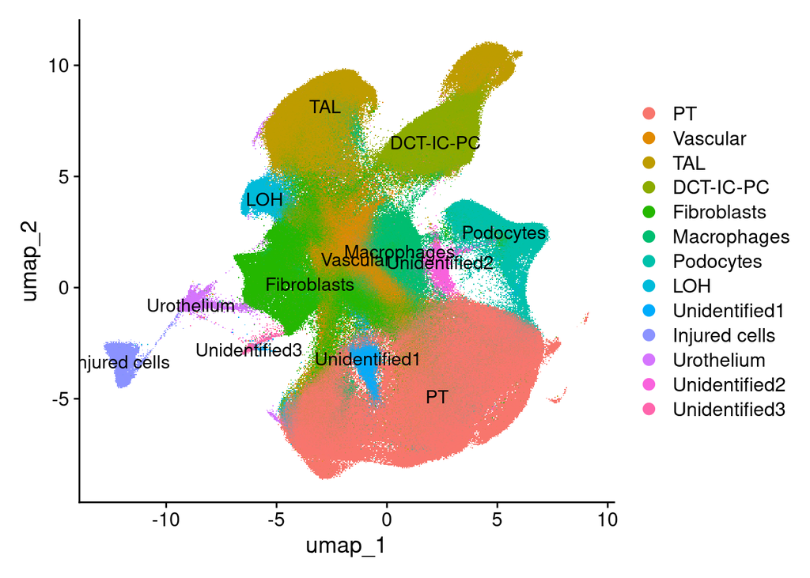

```r
DimPlot(xenium.obj.0027119, label = T)
```

ImagePlot after changing cluster names

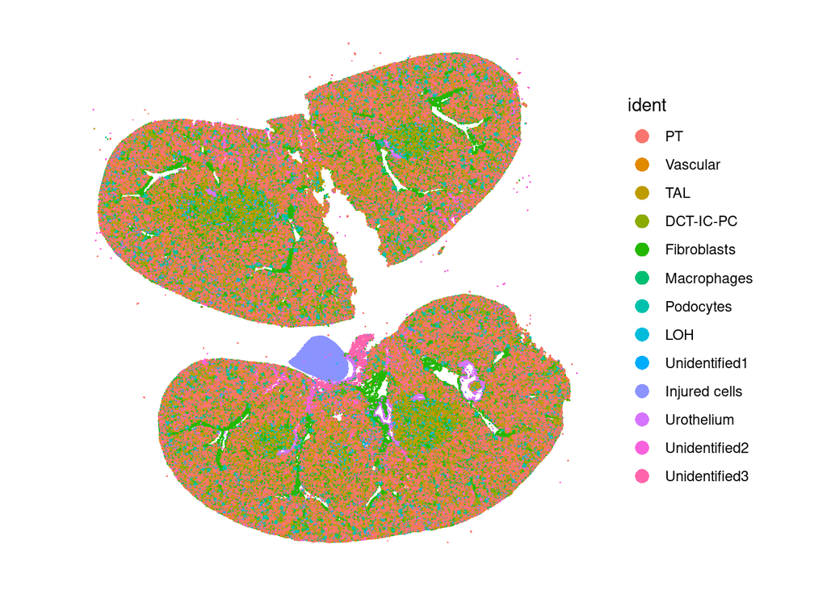

```r
ImageDimPlot(xenium.obj.0027119, dark.background = F)
```